# Презентация по лабораторной работе 3

Математическое моделирование

Нджову Нелиа

1032239033@rudn.ru

Российский университет дружбы народов

## Цель работы

Целью данной лабораторной работы является построение математической модели боевых действий

## Задание

**Вариант 64**

Между страной Х и страной У идет война. Численность состава войск исчисляется от начала войны, и являются временными функциями x(t) и y(t).В начальный момент времени страна Х имеет армию численностью 118 000 человек, а в распоряжении страны У армия численностью в 90 000 человек. Для упрощения модели считаем, что коэффициенты a,b,c,h постоянны.Также считаем P(t) и Q(t) непрерывные функции.

Постройте графики изменения численности войск армии Х и армии У для следующих случаев:

## Задание

1. Модель боевых действий между регулярными войсками
   $$\begin{cases}
   \dfrac{dx}{dt} = -0,555x(t)-0,666y(t)+2\cos{t}\\
   \dfrac{dy}{dt} = -0,444x(t)-0,777y(t)+2\sin{t}
   \end{cases}$$
   {#eq:eq:aa}

## Задание

2. Модель ведение боевых действий с участием регулярных войск и партизанских отрядов

$$\begin{cases}
\dfrac{dx}{dt} = -0,231x(t)-0,785y(t)+\cos{2t}\\
\dfrac{dy}{dt} = -0,451x(t)y(t)-0,158y(t)+\sin{3t}
\end{cases}$$
{#eq:eq:aaa}

## Модели боевых действий

Модели Ланчестера (уравнения Осипова-Ланчестера) описывают динамику боевых действий между двумя противоборствующими сторонами. Основной характеристикой соперников является численность войск x(t) и y(t). Сторона считается проигравшей, если её численность в какой-то момент времени обращается в ноль (при положительной численности противника).

## 1. Модель боевых действий между регулярными войсками

Численность регулярных войск определяется тремя факторами: - **Потери, не связанные с боевыми действиями** (болезни, травмы, дезертирство) - **Потери от боевых действий** противоборствующих сторон - **Поступление подкрепления** P(t) и Q(t)

## 1. Модель боевых действий между регулярными войсками

Система дифференциальных уравнений:

$$\begin{cases}
\dfrac{dx}{dt} = -a(t)x(t) - b(t)y(t) + P(t) \\
\dfrac{dy}{dt} = -c(t)x(t) - h(t)y(t) + Q(t)
\end{cases}$$
{#eq:eq:a}

## 1. Модель боевых действий между регулярными войсками

где: - a(t), h(t) — коэффициенты, характеризующие потери, не связанные с боевыми действиями - b(t), c(t) — эффективность боевых действий сторон (качество стратегии, вооружения, профессионализм) - P(t), Q(t) — функции подкрепления

## 2. Модель с участием регулярных войск и партизанских отрядов

Партизанские отряды менее уязвимы, так как действуют скрытно. Противник вынужден действовать неизбирательно, по площадям. Темп потерь партизан пропорционален не только численности регулярных войск, но и численности самих партизан.

Система уравнений:

$$\begin{cases}
\dfrac{dx}{dt} = -a(t)x(t) - b(t)y(t) + P(t) \\
\dfrac{dy}{dt} = -c(t)x(t)y(t) - h(t)y(t) + Q(t)
\end{cases}$$
{#eq:eq:a}

## 3. Модель боевых действий между партизанскими отрядами

$$\begin{cases}
\dfrac{dx}{dt} = -a(t)x(t) - b(t)x(t)y(t) + P(t) \\
\dfrac{dy}{dt} = -c(t)x(t)y(t) - h(t)y(t) + Q(t)
\end{cases}$$
{#eq:eq:a}

## 4. Простейшая (жесткая) модель

При упрощении (постоянные коэффициенты, отсутствие небоевых потерь и подкреплений):

$$\begin{cases}
\dfrac{dx}{dt} = - by\\
\dfrac{dy}{dt} = -cx
\end{cases}$$
{#eq:eq:a}

## 4. Простейшая (жесткая) модель

Данная система имеет точное решение:
$$cx^2 - by^2 = C$$

Эволюция численностей происходит вдоль гипербол. Если начальная точка лежит выше прямой $cx = by$, выигрывает армия Y; если ниже — выигрывает армия X. На разделяющей прямой война заканчивается истреблением обеих армий за бесконечное время.

*Важный вывод:* для борьбы с вдвое более многочисленным противником требуется в четыре раза более мощное оружие, с втрое более многочисленным — в девять раз и т.д. (квадратичная зависимость).

## 5. Упрощение модели с партизанскими войсками

$$\begin{cases}
\dfrac{dx}{dt} = - by\\
\dfrac{dy}{dt} = -cxy
\end{cases}$$
{#eq:eq:a}

## 5. Упрощение модели с партизанскими войсками

Приводится к уравнению:
$$\dfrac{d}{dt}\left(\frac{b}{2}x^2(t) - cy(t)\right) = 0$$

Которое имеет решение:
$$\dfrac{b}{2}x^2(t) - cy(t) = \frac{b}{2}x^2(0) - cy(0) = C_1$$

- При $C_1 > 0$ побеждает регулярная армия
- При $C_1 < 0$ побеждают партизаны

*Вывод:* регулярные войска находятся в более выгодном положении, так как для победы им требуется меньший рост начальной численности по сравнению с партизанами (линейный против квадратичного).

## Модель боевых действий между регулярными войсками. Реализация в Julia

Модель боевых действий между регулярными войсками. Я присваиваю значения коэффициенту смертности, который не связан с боевыми операциями, и коэффициентам эффективности первой и второй армий. Значения приведены в задаче.Я использую библиотеки DifferentialEquations для работы с дифференциальными уравнениями и Plots для построения графиков(рис.1).

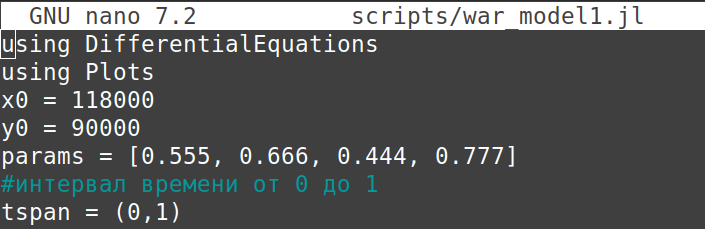

Рисунок 1: Присвоение значений

## Модель боевых действий между регулярными войсками. Реализация в Julia

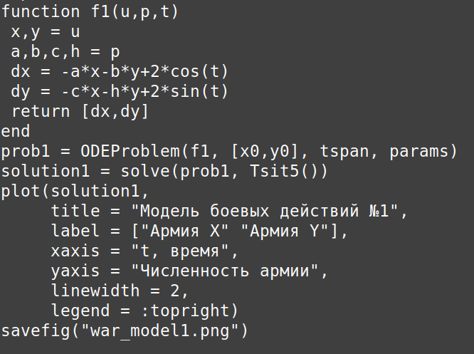

Рисунок 2: Функции

## Модель боевых действий между регулярными войсками. Реализация в Julia

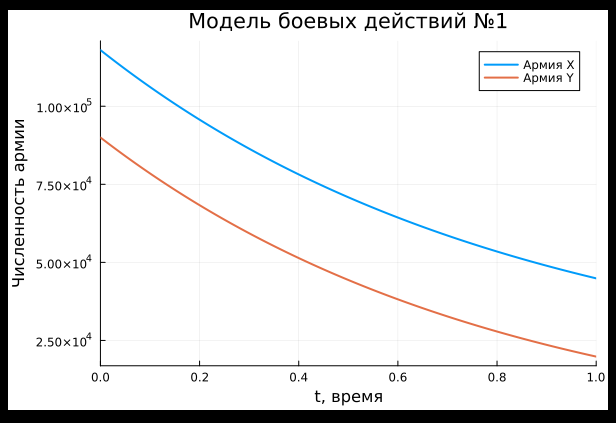

Рисунок 3: Результат

## Модель боевых действий между регулярными войсками. Реализация в scilab

Я создаю ту же модель, используя scilab.Мы видим, что график совпадает с тем, который мы получили с помощью Julia, никакой разницы(рис.4)

## Модель боевых действий между регулярными войсками. Реализация в scilab

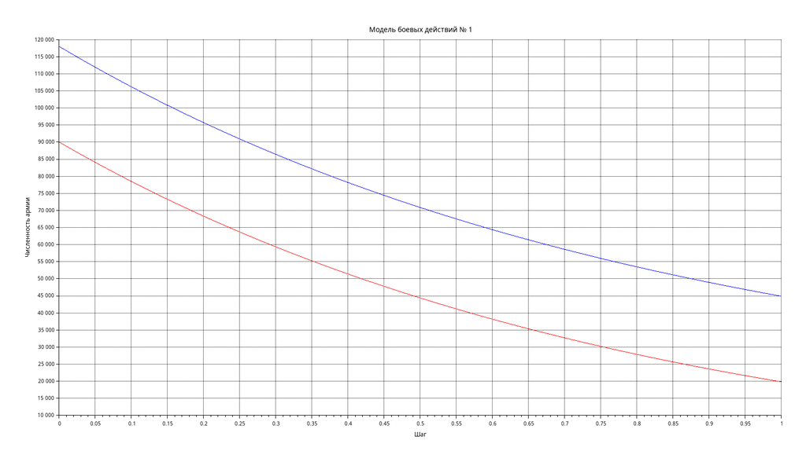

Рисунок 4: Результат

## Модель ведение боевых действий с участием регулярных войск и партизанских отрядов. Реализация в Julia

Модель боевых действий между регулярными войсками. Я присваиваю значения коэффициенту смертности, который не связан с боевыми операциями, и коэффициентам эффективности первой и второй армий. Значения приведены в задаче(рис.5).

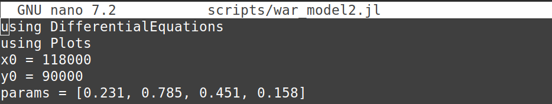

Рисунок 5: Присвоение значений

## Модель ведение боевых действий с участием регулярных войск и партизанских отрядов. Реализация в Julia

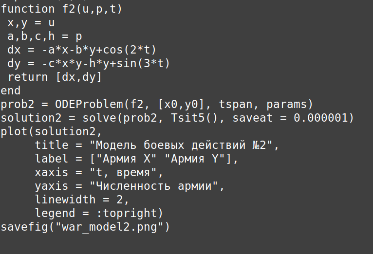

Рисунок 6: Функции

## Модель ведение боевых действий с участием регулярных войск и партизанских отрядов. Реализация в Julia

В результате мы видим, что при таких параметрах модели армия X побеждает за короткий промежуток времени(рис.7)

## Модель ведение боевых действий с участием регулярных войск и партизанских отрядов. Реализация в Julia

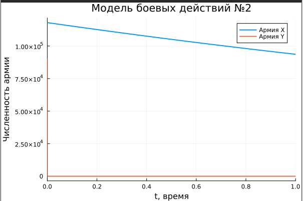

Рисунок 7: Результат

## Модель ведение боевых действий с участием регулярных войск и партизанских отрядов. Реализация в scilab

Я создаю ту же модель, используя scilab. Мы видим, что график совпадает с тем, который мы получили с помощью Julia, никакой разницы(рис.8)

## Модель ведение боевых действий с участием регулярных войск и партизанских отрядов. Реализация в scilab

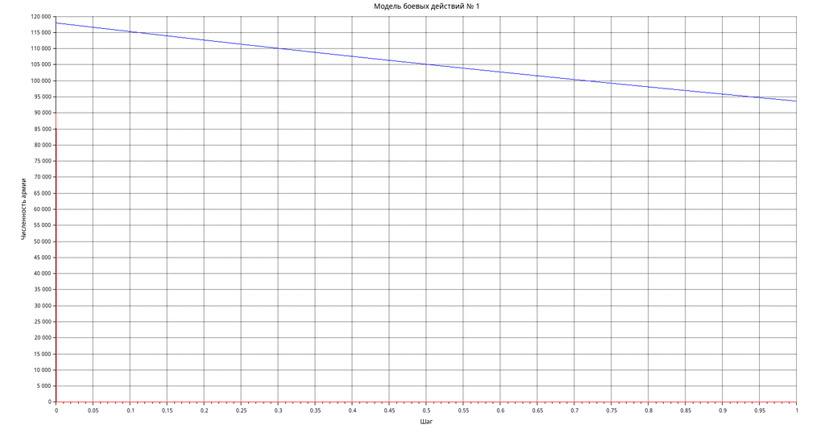

Рисунок 8: Результат

## Модель ведение боевых действий с участием регулярных войск и партизанских отрядов. Реализация в scilab

Чтобы ясно видеть, как уменьшается количество солдат армии Y, я установила пределы x и y от 0,0002 до 40000(рис.9)

## Модель ведение боевых действий с участием регулярных войск и партизанских отрядов. Реализация в scilab

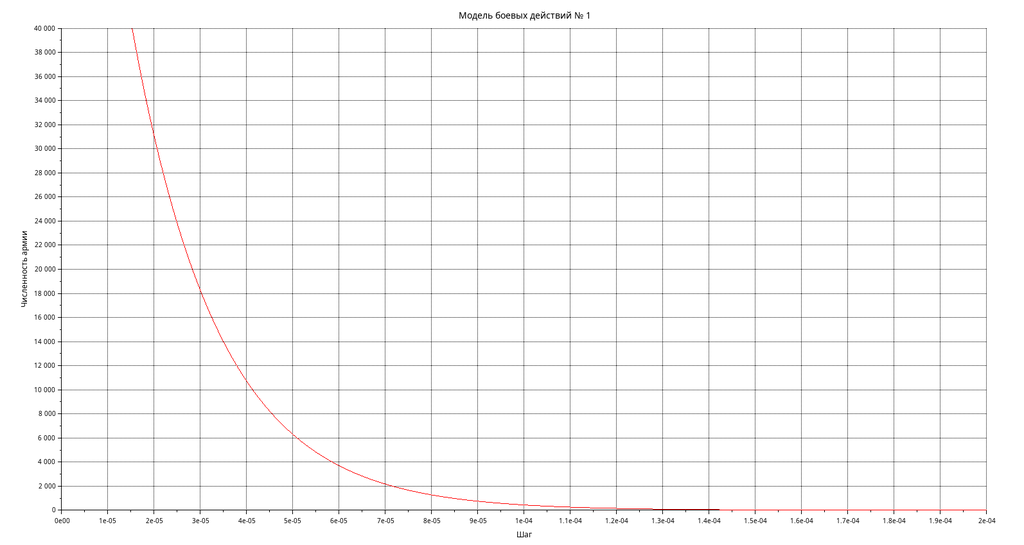

Рисунок 9: Результат

## Выводы

В этой лабораторной работе я построила математическую модель боевых действий.